# project5

2024-05-22

## Part A

### My data context:

I choose the ‘weather of wellington’ as my data context, as I believe there would be a lot of information out there to be scraped, and the weather would be a very public data that can be very impactful for making decisions regarding events or out door activities

```r
library(tidyverse)
library(rvest)

# My data context is the weather of New Zealand, Wellington
# url of weather site for today's weather in nz
url = "https://weather.com/en-NZ/weather/today/l/NZXX0049:1:NZ?Goto=Redirected"
# by changing "today" to "hourbyhour", "weekend", or "monthly" we can get data for different periods of time



# this site is scrapable as the terms and services do not reject data mining
# the robot.txt disallows information to be accessed that is in the back end
page = read_html(url)

current_temp = page %>%
  html_element("div") %>%
  html_element(".CurrentConditions--tempValue--MHmYY") %>%
  html_text2()

current_conditions = page %>%
  html_element("div") %>%
  html_element(".CurrentConditions--phraseValue--mZC_p") %>%
  html_text2()

current_air_quality = page %>%
  html_element("div") %>%
  html_element(".AirQualityText--severity--W9CtX") %>%
  html_text2()

location = page %>%
  html_element("div") %>%
  html_element(".CurrentConditions--location--1YWj_") %>%
  html_text2()

# concatenation of every object ran into a sentence
current_temp
```

```
## [1] "12°"
```

```r
current_conditions
```

```
## [1] "Mostly Cloudy/Wind"
```

```r
current_air_quality
```

```
## [1] "Good"
```

```r
location
```

```
## [1] "Wellington, Wellington"
```

```r
paste0("In ", location, " the temperature now is ", current_temp, "C, ", "the day is looking ", current_conditions, " with ", current_air_quality, " air quality")
```

```
## [1] "In Wellington, Wellington the temperature now is 12°C, the day is looking Mostly Cloudy/Wind with Good air quality"
```

## Part B

```r
library(tidyverse)
library(rvest)

# selected David Seymour


url <- "https://www.beehive.govt.nz/minister/hon-david-seymour"


# in the releases there are high frequency use of quotation marks to quote from the ministers,
# releases end with a link for further/additional information for the topic
#
pages <- read_html(url) %>%
  html_elements(".release__wrapper") %>%
  html_elements("h2") %>%
  html_elements("a") %>%
  html_attr("href") %>%
  paste0("https://www.beehive.govt.nz", .)

pages

# html_elements(".article__title") for title
# html_elements(".prose field field--name-body field--type-text-with-summary field--label-hidden field--item")

release_url = "https://www.beehive.govt.nz/release/unions-should-put-learning-ahead-ideology"

content <- read_html(release_url) %>%
    html_element(".prose field field--name-body field--type-text-with-summary field--label-hidden field--item") %>%
    html_element("div") %>%
    html_text2()

title <- read_html(release_url) %>%
  html_element(".article__title") %>%
  html_text2()


page_url <- pages[1]

page <- read_html(page_url)

release_title <- page %>%
  html_element(".article__title") %>%
  html_text2()

release_content <- page %>%
  html_elements("p") %>%
  html_text2()

release_title
release_content

get_release <- function(page_url){
  Sys.sleep(2)
  # print the page_url so if things go wrong
  # we can see which page caused issues
  print(page_url)
  page <- read_html(page_url)

  # add code to scrape the release title and release content
  release_title <- page %>%
    html_element(".article__title") %>%
    html_text2()

  release_content <- page %>%
    html_elements(".prose.field.field--name-body.field--type-text-with-summary.field--label-hidden.field--item") %>%
    html_elements("p") %>%
    html_text2()
  # add code to return a tibble created using these data objects
  df = tibble(title = release_title, content = release_content)
  return(df)
}

release_data <- map_df(pages, get_release)

release_data
# use summarise
# find mean
# find total
# find longest
# find shortest
total_char = release_data$content %>%
  nchar() %>%
  sum()

mean_nchar_rounded = release_data$content %>%
  nchar() %>%
  mean() %>%
  round(0)

median_nchar = release_data$content %>%
  nchar() %>%
  median()

largest_nchar = release_data$content %>%
  nchar() %>%
  max()

total_char
mean_nchar_rounded
median_nchar
largest_nchar
```

[output not shown]

the total number of characters in Seymour’s release content is $50126$ the mean number of character in Seymour’s release content is $218$ the median number of character in Seymour’s release content is $213$ the longest number of characters in Seymour’s release content per paragraph is $498$

## Part C

- I made a bar graph, where each bar is the total number of speeches that year, and the different colours of the bar correspond to the portions of speeches in regard of the keywords
- the visualisation shows that the total number of speeches regarding the topics of collaboration, education, and employment increased from 1996 to 2006, and the years afterwards have been decreasing (until 2023)
- the visualisation also reveals that out of the 3, that collaboration as a topic of speech is the lowest compared to the other two topics and education and employment being similar

```r
library(tidyverse)
library(rvest)

keywords <- c("education", "collaboration", "employment")

search1 <- read_html(paste0("https://datalandscapes.online/scrapeable/speeches.php?search=", keywords[1])) %>%
  html_elements(".speech_summary") %>%
  html_text2() %>%
  tibble(keyword = keywords[1],
         results = .) %>%
  separate(results, into = c("year", "num_speeches"), sep = "--") %>%
  mutate(num_speeches = parse_number(num_speeches),
         year = parse_number(year))

search2 <- read_html(paste0("https://datalandscapes.online/scrapeable/speeches.php?search=", keywords[2])) %>%
  html_elements(".speech_summary") %>%
  html_text2() %>%
  tibble(keyword = keywords[2],
         results = .) %>%
  separate(results, into = c("year", "num_speeches"), sep = "--") %>%
  mutate(num_speeches = parse_number(num_speeches),
         year = parse_number(year))

search3 <- read_html(paste0("https://datalandscapes.online/scrapeable/speeches.php?search=", keywords[3])) %>%
  html_elements(".speech_summary") %>%
  html_text2() %>%
  tibble(keyword = keywords[3],
         results = .) %>%
  separate(results, into = c("year", "num_speeches"), sep = "--") %>%
  mutate(num_speeches = parse_number(num_speeches),
         year = parse_number(year))

search1
```

```
## # A tibble: 28 × 3
##    keyword    year num_speeches
##    <chr>     <dbl>        <dbl>
##  1 education  2023           25
##  2 education  2022           43
##  3 education  2021           60
##  4 education  2020           31
##  5 education  2019           74
##  6 education  2018           89
##  7 education  2017           41
##  8 education  2016           53
##  9 education  2015           73
## 10 education  2014           67
## # ℹ 18 more rows
```

```r
search2
```

```
## # A tibble: 28 × 3
##    keyword        year num_speeches
##    <chr>         <dbl>        <dbl>
##  1 collaboration  2023           35
##  2 collaboration  2022           50
##  3 collaboration  2021           61
##  4 collaboration  2020           21
##  5 collaboration  2019           64
##  6 collaboration  2018           79
##  7 collaboration  2017           29
##  8 collaboration  2016           46
##  9 collaboration  2015           52
## 10 collaboration  2014           57
## # ℹ 18 more rows
```

```r
search3
```

```
## # A tibble: 28 × 3
##    keyword     year num_speeches
##    <chr>      <dbl>        <dbl>
##  1 employment  2023           24
##  2 employment  2022           34
##  3 employment  2021           53
##  4 employment  2020           32
##  5 employment  2019           56
##  6 employment  2018           72
##  7 employment  2017           35
##  8 employment  2016           24
##  9 employment  2015           60
## 10 employment  2014           67
## # ℹ 18 more rows
```

```r
combined_search <- bind_rows(search1, search2, search3)
combined_search
```

```
## # A tibble: 84 × 3
##    keyword    year num_speeches
##    <chr>     <dbl>        <dbl>
##  1 education  2023           25
##  2 education  2022           43
##  3 education  2021           60
##  4 education  2020           31
##  5 education  2019           74
##  6 education  2018           89
##  7 education  2017           41
##  8 education  2016           53
##  9 education  2015           73
## 10 education  2014           67
## # ℹ 74 more rows
```

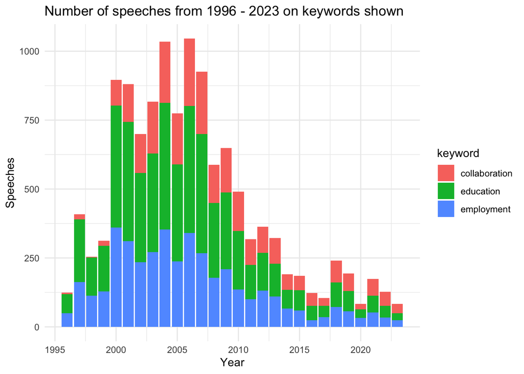

```r
view(combined_search)

speeches_governments <- read_csv("https://docs.google.com/spreadsheets/d/e/2PACX-1vRHTFJcFmsIkjaFUCEwFWASaBOAR4X2Upx66C5Bhgc_WNc2JxxdRbbvyoewmvt_EjNdCNZZzzkENwLg/pub?gid=0&single=true&output=csv")
view(speeches_governments)
speech_data <- left_join(combined_search, speeches_governments, by = "year")
view(speech_data)

graph <- speech_data %>%
  ggplot(aes(x = year, y = num_speeches, fill = keyword)) +
  geom_bar(stat = "identity") +
  labs(title = "Number of speeches from 1996 - 2023 on keywords shown",
       x = "Year",
       y = "Speeches",
       fill = "keyword") +
  theme_minimal()

graph
```

## Learning reflection

- I learnt how to webscrape and how to check the robots.txt on website to see what actions are allowed and what actions are not. I have learnt how to efficiently look into html of websites that are scrappable and process them into csv’s and then dataframes for statsitical and data visualisation with R.
- I would like to look into how to make better webscrapers or maybe APIs that Anna made for us in the previous projects to scrape Youtube comments or other information

## Self reflection

- The two most important skills I have learnt through these projects are webscraping and data visualization. I believe that webscraping opens up many opportunities for me to access the vast amounts of data on the internet for either statistical analysis or for may be in the future training machine learning models. Data visualization is also important in the sense that it helps seeing complex sets of data in a visual style so that it becomes more accessible for everyone including those with limited statistics backgrounds, and it will surely help with making informative decisions.